# Importing dataset and null value treatment

# PCA after splitting

```python
X_train, X_test, y_train, y_test = train_test_split(X, y, test_size=0.30, random_state=10)
```

```python
from sklearn.preprocessing import StandardScaler

# creating a standard scaler
sc = StandardScaler()

# fitting independent data to the model
X_trainScaled = sc.fit_transform(X_train)
X_testScaled = sc.fit_transform(X_test)
#x_test = sc.transform(x_test)
```

```python
from imblearn.over_sampling import SMOTE

sm = SMOTE(random_state=42)

X_trainScaled, y_trainScaled = sm.fit_sample(X_train1, y_train1)
```

```python
#Using 150 components and printing the eigen vectors
pca150 = PCA(n_components=150)
pca150.fit(X_trainScaled)
#print(pca150.components_)
#print(pca150.explained_variance_ratio_)
X_train = pca150.transform(X_trainScaled)
```

```python
#Using 150 components and printing the eigen vectors
pca150 = PCA(n_components=150)
pca150.fit(X_testScaled)
#print(pca150.components_)
#print(pca150.explained_variance_ratio_)
X_test = pca150.transform(X_testScaled)
```

```
LR
             precision    recall  f1-score   support

         -1       0.93      0.60      0.73       440
          1       0.06      0.39      0.11        31

avg / total       0.88      0.59      0.69       471

XGB
             precision    recall  f1-score   support

         -1       0.93      0.98      0.96       440
          1       0.00      0.00      0.00        31

avg / total       0.87      0.92      0.89       471

KNN
             precision    recall  f1-score   support

         -1       1.00      0.02      0.04       440
          1       0.07      1.00      0.13        31

avg / total       0.94      0.08      0.04       471

DT
             precision    recall  f1-score   support

         -1       0.93      0.79      0.86       440
          1       0.06      0.19      0.09        31

avg / total       0.88      0.75      0.81       471

RF
             precision    recall  f1-score   support

         -1       0.93      1.00      0.97       440
          1       0.00      0.00      0.00        31

avg / total       0.87      0.93      0.90       471

ADA
             precision    recall  f1-score   support

         -1       0.93      0.96      0.95       440
          1       0.00      0.00      0.00        31

avg / total       0.87      0.90      0.89       471

SVC
             precision    recall  f1-score   support

         -1       0.93      0.99      0.96       440
          1       0.00      0.00      0.00        31

avg / total       0.87      0.92      0.90       471
```

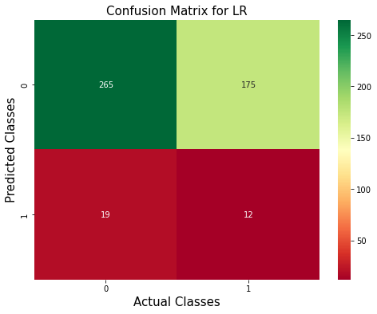

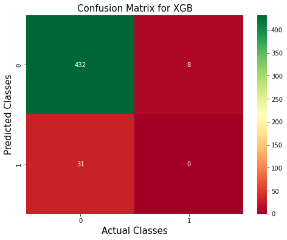

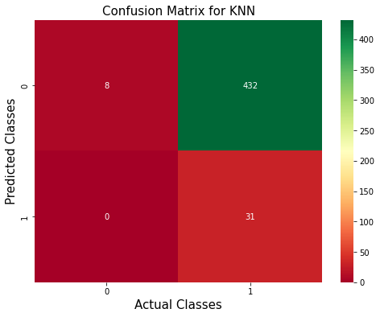

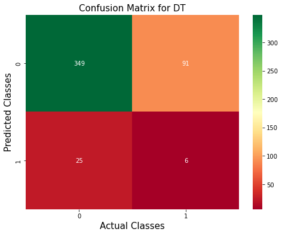

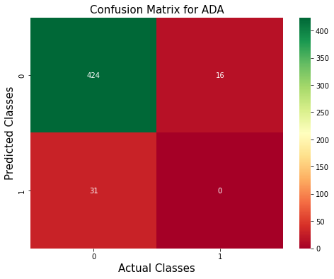

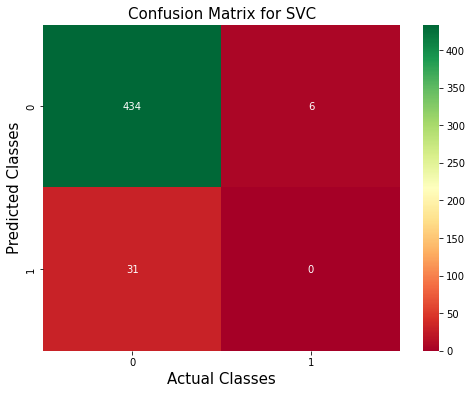

```python
xgb = XGBClassifier()
logreg= LogisticRegression()
knn = KNeighborsClassifier()
svcl = SVC()

adb = AdaBoostClassifier()

dtclf =DecisionTreeClassifier()
rfclf =RandomForestClassifier()



#prepare configuration for cross validation test harness
seed = 42

# prepare models

models = []
models.append(('LR', LogisticRegression()))
models.append(('XGB', XGBClassifier(random_state=1, eval_metric='mlogloss')))
models.append(('KNN', KNeighborsClassifier(5)))
models.append(('DT', DecisionTreeClassifier(max_depth=5)))
models.append(('RF', RandomForestClassifier(n_estimators=196)))
models.append(('ADA', AdaBoostClassifier()))
models.append(('SVC', SVC()))
xgb = XGBClassifier()
logreg= LogisticRegression()
knn = KNeighborsClassifier()
svcl = SVC()

adb = AdaBoostClassifier()

dtclf =DecisionTreeClassifier()
rfclf =RandomForestClassifier()


#prepare configuration for cross validation test harness
seed = 42

# prepare models

models = []
models.append(('LR', LogisticRegression()))
models.append(('XGB', XGBClassifier(random_state=1, eval_metric='mlogloss')))
models.append(('KNN', KNeighborsClassifier(5)))
models.append(('DT', DecisionTreeClassifier(max_depth=5)))
models.append(('RF', RandomForestClassifier(n_estimators=196)))
models.append(('ADA', AdaBoostClassifier()))
models.append(('SVC', SVC()))


#evaluate each model in turn

results = []
names = []
scoring = 'accuracy'
precision=[]
recall=[]

for name, model in models:

    clf = model.fit(X_train, y_train)
    pred = clf.predict(X_test)

    cv_results=accuracy_score(y_test, pred)


    tn, fp, fn, tp = confusion_matrix(y_test,pred).ravel()
        #visualization of confusion matrix in the form of a heatmap

    cm= confusion_matrix(y_test, pred)
    plt.figure(figsize = (8, 6))
    sns.heatmap(cm, annot = True, cmap = 'RdYlGn', fmt = 'd')
    plt.xlabel('Actual Classes', fontsize = 15)
    plt.ylabel('Predicted Classes', fontsize = 15)
    plt.title('Confusion Matrix for '+ str(name), fontsize = 15);
    plt.show
    print(name)
    print(classification_report(y_test, pred))

    recallv = round(tp/(tp+fn), 3)
    precisionv = round(tp/(tp+fp), 3)
    recall.append(recallv)
    precision.append(precisionv)

    results.append(cv_results)
    names.append(name)
    msg = "%s: %f %f %f" % (name, cv_results.mean(), precisionv,recallv)
   # print(msg)
```

```python
result_pca_ = pd.DataFrame({'Model' : names,
                       'Accuracy' : results,
                      'Recall' : recall,
                      'Precision' : precision,
                      })
result_pca_
```

|  | Model | Accuracy | Recall | Precision |
| --- | --- | --- | --- | --- |
| 0 | LR | 0.588110 | 0.387 | 0.064 |
| 1 | XGB | 0.917197 | 0.000 | 0.000 |
| 2 | KNN | 0.082803 | 1.000 | 0.067 |
| 3 | DT | 0.753715 | 0.194 | 0.062 |
| 4 | RF | 0.934183 | 0.000 | NaN |
| 5 | ADA | 0.900212 | 0.000 | 0.000 |
| 6 | SVC | 0.921444 | 0.000 | 0.000 |

```python
df_models=pd.concat([result, result_sm, result_os, result_pca_],axis=1)
```

# Comparing the results

```python
print('         Normal_data,            SMOTE,                          Oversampling,                    PCA_with_SMOTE')
df_models
```

```
         Normal_data,            SMOTE,                          Oversampling,                    PCA_with_SMOTE
```

|  | Model | Accuracy | Recall | Precision | Model | Accuracy | Recall | Precision | Model | Accuracy | Recall | Precision | Model | Accuracy | Recall | Precision |
| --- | --- | --- | --- | --- | --- | --- | --- | --- | --- | --- | --- | --- | --- | --- | --- | --- |
| 0 | LR | 0.588110 | 0.387 | 0.064 | LR | 0.813163 | 0.387 | 0.148 | LR | 0.813163 | 0.387 | 0.148 | LR | 0.588110 | 0.387 | 0.064 |
| 1 | XGB | 0.917197 | 0.000 | 0.000 | XGB | 0.800425 | 0.290 | 0.111 | XGB | 0.932059 | 0.000 | 0.000 | XGB | 0.917197 | 0.000 | 0.000 |
| 2 | KNN | 0.082803 | 1.000 | 0.067 | KNN | 0.186837 | 1.000 | 0.075 | KNN | 0.821656 | 0.323 | 0.137 | KNN | 0.082803 | 1.000 | 0.067 |
| 3 | DT | 0.753715 | 0.194 | 0.062 | DT | 0.630573 | 0.452 | 0.082 | DT | 0.711253 | 0.387 | 0.093 | DT | 0.753715 | 0.194 | 0.062 |
| 4 | RF | 0.934183 | 0.000 | NaN | RF | 0.934183 | 0.000 | NaN | RF | 0.934183 | 0.000 | NaN | RF | 0.934183 | 0.000 | NaN |
| 5 | ADA | 0.900212 | 0.000 | 0.000 | ADA | 0.783439 | 0.161 | 0.062 | ADA | 0.857749 | 0.097 | 0.071 | ADA | 0.900212 | 0.000 | 0.000 |
| 6 | SVC | 0.921444 | 0.000 | 0.000 | SVC | 0.927813 | 0.000 | 0.000 | SVC | 0.925690 | 0.000 | 0.000 | SVC | 0.921444 | 0.000 | 0.000 |

Among all the models logistic regression and Decision Tree with oversampling are giving better accuracy and recall. PCA is not giving good results. In our problem recall is more important than accuracy as 94% is class -1 and the other models are not properly predicting the other class.

We will choose these two models and will do hyperparameter tuning and cross validation and then we will select one model.

# Feature importance

```python
X_train, X_test,y_train, y_test = X_train1, X_test1,y_train1, y_test1
X_train, y_train = os.fit_sample(X_train, y_train)
```

```python
dt = DecisionTreeClassifier()
#dt=DecisionTreeClassifier(max_depth=5)
dt=dt.fit(X_train_os, y_train_os)
```

```python
dt
```

```
DecisionTreeClassifier(class_weight=None, criterion='gini', max_depth=None,
            max_features=None, max_leaf_nodes=None,
            min_impurity_decrease=0.0, min_impurity_split=None,
            min_samples_leaf=1, min_samples_split=2,
            min_weight_fraction_leaf=0.0, presort=False, random_state=None,
            splitter='best')
```

```python
df_fi = pd.DataFrame(data = X_train)
```

```python
#
pd.Series(dt.feature_importances_, df_fi.columns ).sort_values(ascending= False).head(10)
```

```
85     0.126893
107    0.076583
143    0.060590
108    0.053942
50     0.052132
209    0.040641
301    0.039567
123    0.037776
355    0.037361
10     0.031375
dtype: float64
```

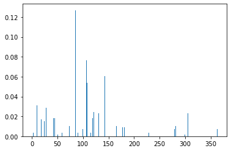

```python
# feature importance
#print(dt.feature_importances_)
# plot
plt.bar(range(len(dt.feature_importances_)), dt.feature_importances_)
plt.show()
```

```python
pred = dt.predict(X_test)

score=accuracy_score(y_test, pred)

cm= confusion_matrix(y_test, pred)
```

```python
score
```

```
0.8471337579617835
```

```
DT
             precision    recall  f1-score   support

         -1       0.93      0.90      0.92       440
          1       0.06      0.10      0.08        31

avg / total       0.88      0.85      0.86       471
```

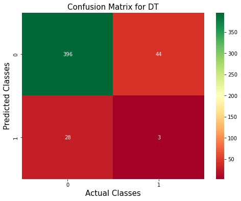

```python
name='DT'
cm= confusion_matrix(y_test, pred)
plt.figure(figsize = (8, 6))
sns.heatmap(cm, annot = True, cmap = 'RdYlGn', fmt = 'd')
plt.xlabel('Actual Classes', fontsize = 15)
plt.ylabel('Predicted Classes', fontsize = 15)
plt.title('Confusion Matrix for '+ str(name), fontsize = 15);
plt.show
print('DT')
print(classification_report(y_test, pred))
```

Applying grid search cv

```python
from sklearn.model_selection import GridSearchCV

parameters = {
 'max_depth': [4,5,10, 20, 30,40,50],
 'max_features': ['auto', 'sqrt'],
 'min_samples_leaf': [1, 2, 4, 8],
 }


dt = GridSearchCV(DecisionTreeClassifier(), parameters, cv = 5, verbose = 2, n_jobs= 4)
dt.fit(X_train_os, y_train_os)

dt.best_params_
```

```
Fitting 5 folds for each of 56 candidates, totalling 280 fits
```

```
[Parallel(n_jobs=4)]: Done  35 tasks      | elapsed:    2.8s
[Parallel(n_jobs=4)]: Done 280 out of 280 | elapsed:    5.4s finished
```

```
{'max_depth': 50, 'max_features': 'auto', 'min_samples_leaf': 1}
```

```python
DecisionTreeClassifier().get_params().keys()
```

```
dict_keys(['class_weight', 'criterion', 'max_depth', 'max_features', 'max_leaf_nodes', 'min_impurity_decrease', 'min_impurity_split', 'min_samples_leaf', 'min_samples_split', 'min_weight_fraction_leaf', 'presort', 'random_state', 'splitter'])
```

```python
#dt = DecisionTreeClassifier()
dt=DecisionTreeClassifier(max_depth=50, min_samples_leaf=1)
dt=dt.fit(X_train_os, y_train_os)
pred = dt.predict(X_test)
```

```python
accuracy_score(y_test, pred)
```

```
0.6985138004246284
```

```
             precision    recall  f1-score   support

         -1       0.95      0.71      0.82       440
          1       0.11      0.48      0.17        31

avg / total       0.90      0.70      0.77       471
```

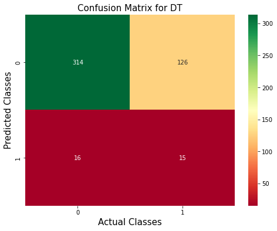

```python
cm= confusion_matrix(y_test, pred)
plt.figure(figsize = (8, 6))
sns.heatmap(cm, annot = True, cmap = 'RdYlGn', fmt = 'd')
plt.xlabel('Actual Classes', fontsize = 15)
plt.ylabel('Predicted Classes', fontsize = 15)
plt.title('Confusion Matrix for '+ str(name), fontsize = 15);
plt.show

print(classification_report(y_test, pred))
```

```python
lr = LogisticRegression()

lr=lr.fit(X_train_os, y_train_os)
pred = lr.predict(X_test)
score=lr.score(X_train_os, y_train_os)
scorecv = cross_val_score(lr, X, y, cv = 6).mean()
print(f'score  = {score}')
print(f'Cross validation score  = {scorecv}')
```

```
score  = 0.97702834799609
Cross validation score  = 0.8980040294004495
```

```python
name='LR'
cm= confusion_matrix(y_test, pred)
plt.figure(figsize = (8, 6))
sns.heatmap(cm, annot = True, cmap = 'RdYlGn', fmt = 'd')
plt.xlabel('Actual Classes', fontsize = 15)
plt.ylabel('Predicted Classes', fontsize = 15)
plt.title('Confusion Matrix for '+ str(name), fontsize = 15);
plt.show

print(classification_report(y_test, pred))
```

```
             precision    recall  f1-score   support

         -1       0.95      0.84      0.89       440
          1       0.15      0.39      0.21        31

avg / total       0.90      0.81      0.85       471
```

```python
grid_values = {'penalty': ['l1','l2'],
               'C': [0.001,0.01,0.1,1,10,100,1000]}
model_lr = GridSearchCV(lr, param_grid=grid_values)
model_lr.fit(X, y)

model_lr.best_params_
```

```
{'C': 0.001, 'penalty': 'l1'}
```

```python
lr = LogisticRegression(C=0.01,penalty='l1')

lr=lr.fit(X_train_os, y_train_os)
pred = lr.predict(X_test)
#score=lr.score(X_train_os, y_train_os)
#scorecv = cross_val_score(lr, X, y, cv = 6).mean()
#print(f'score  = {score}')
#print(f'Cross validation score  = {scorecv}')
```

```python
accuracy_score(y_test, pred)
```

```
0.5753715498938429
```

# cross validation score

```python
cross_val_score(lr, X_train_os, y_train_os, cv = 5).mean()
```

```
0.6764395026303204
```

```python
recall_score(y_test, pred)
```

```
0.6774193548387096
```

```
             precision    recall  f1-score   support

         -1       0.96      0.57      0.71       440
          1       0.10      0.68      0.17        31

avg / total       0.90      0.58      0.68       471
```

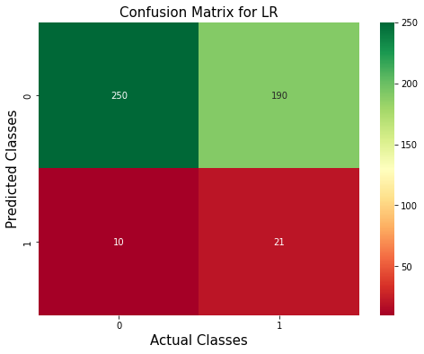

```python
cm= confusion_matrix(y_test, pred)
plt.figure(figsize = (8, 6))
sns.heatmap(cm, annot = True, cmap = 'RdYlGn', fmt = 'd')
plt.xlabel('Actual Classes', fontsize = 15)
plt.ylabel('Predicted Classes', fontsize = 15)
plt.title('Confusion Matrix for '+ str(name), fontsize = 15);
plt.show

print(classification_report(y_test, pred))
```

Final model is taken as logistic regression as it is able to predict both the classes and giving good recall and accuracy

Pickling the final model

```python
import pickle
```

```python
Pkl_Filename = "Pickle_RL_Model.pkl"

with open(Pkl_Filename, 'wb') as file:
    pickle.dump(lr, file)

# Load the Model back from file
with open(Pkl_Filename, 'rb') as file:
    Pickled_LR_Model = pickle.load(file)

Pickled_LR_Model
```

```
LogisticRegression(C=0.01, class_weight=None, dual=False, fit_intercept=True,
          intercept_scaling=1, max_iter=100, multi_class='ovr', n_jobs=1,
          penalty='l1', random_state=None, solver='liblinear', tol=0.0001,
          verbose=0, warm_start=False)
```

# Predicting results on future data

```python
dft=pd.read_excel('Future_predictions.xlsx')
```

```python
dft.drop('Time',axis=1,inplace=True)
```

```python
dft.fillna(0, inplace=True)
```

```python
print()
print(to_drop)
```

```
['18', '25', '27', '30', '31', '46', '50', '51', '54', '60', '62', '65', '66', '70', '101', '123', '124', '127', '153', '154', '169', '174', '187', '201', '202', '203', '247', '250', '270', '271', '272', '273', '274', '275', '277', '278', '279', '280', '282', '283', '285', '286', '287', '288', '289'…
```

```python
res = ' '.join(map(str, to_drop))
print("Converting list to string using map() method:\n")
print(res)
```

```
Converting list to string using map() method:

18 25 27 30 31 46 50 51 54 60 62 65 66 70 101 123 124 127 153 154 169 174 187 201 202 203 247 250 270 271 272 273 274 275 277 278 279 280 282 283 285 286 287 288 289 290 291 294 295 296 297 298 299 300 302 303 304 305 306 307 308 309 310 311 312 316 317 318 319 320 321 323 324 331 332 333 334 335 33…
```

```python
res.replace(' ',',')
```

```
'18,25,27,30,31,46,50,51,54,60,62,65,66,70,101,123,124,127,153,154,169,174,187,201,202,203,247,250,270,271,272,273,274,275,277,278,279,280,282,283,285,286,287,288,289,290,291,294,295,296,297,298,299,300,302,303,304,305,306,307,308,309,310,311,312,316,317,318,319,320,321,323,324,331,332,333,334,335,3…
```

```python
dft.drop([18,25,27,30,31,46,50,51,54,60,62,65,66,70,101,123,124,127,153,154,169,174,187,201,202,203,247,250,270,271,272,273,274,275,277,278,279,280,282,283,285,286,287,288,289,290,291,294,295,296,297,298,299,300,302,303,304,305,306,307,308,309,310,311,312,316,317,318,319,320,321,323,324,331,332,333,334,335,337,338,339,340,341,343,344,348,349,350,351,352,353,354,355,356,357,359,360,361,362,363,365,376,377,385,386,388,389,390,391,392,393,405,406,407,408,409,410,411,412,413,415,416,420,421,424,425,426,427,428,429,430,431,434,435,436,437,438,439,440,441,442,443,444,445,446,447,448,452,453,454,455,456,457,459,467,469,470,471,473,474,475,477,479,480,490,491,493,494,495,496,497,519,520,522,523,524,525,526,527,539,540,541,552,553,554,555,556,557,561,564,566,567,568,569,574,575,576,585],axis=1,inplace=True)
```

```python
dft
```

|  | 0 | 1 | 2 | 3 | 4 | 5 | 6 | 7 | 8 | 9 | ... | 579 | 580 | 581 | 582 | 583 | 584 | 586 | 587 | 588 | 589 |
| --- | --- | --- | --- | --- | --- | --- | --- | --- | --- | --- | --- | --- | --- | --- | --- | --- | --- | --- | --- | --- | --- |
| 0 | 3030.93 | 2564.00 | 2187.7333 | 1411.1265 | 1.3602 | 100 | 97.6133 | 0.1242 | 1.5005 | 0.0162 | ... | 0.0000 | 0.0000 | 0.0000 | 0.5005 | 0.0118 | 0.0035 | 0.0000 | 0.0000 | 0.0000 | 0.0000 |
| 1 | 3095.78 | 2465.14 | 2230.4222 | 1463.6606 | 0.8294 | 100 | 102.3433 | 0.1247 | 1.4966 | -0.0005 | ... | 0.0201 | 0.0060 | 208.2045 | 0.5019 | 0.0223 | 0.0055 | 0.0096 | 0.0201 | 0.0060 | 208.2045 |
| 2 | 2932.61 | 2559.94 | 2186.4111 | 1698.0172 | 1.5102 | 100 | 95.4878 | 0.1241 | 1.4436 | 0.0041 | ... | 0.0484 | 0.0148 | 82.8602 | 0.4958 | 0.0157 | 0.0039 | 0.0584 | 0.0484 | 0.0148 | 82.8602 |
| 3 | 2988.72 | 2479.90 | 2199.0333 | 909.7926 | 1.3204 | 100 | 104.2367 | 0.1217 | 1.4882 | -0.0124 | ... | 0.0149 | 0.0044 | 73.8432 | 0.4990 | 0.0103 | 0.0025 | 0.0202 | 0.0149 | 0.0044 | 73.8432 |
| 4 | 3032.24 | 2502.87 | 2233.3667 | 1326.5200 | 1.5334 | 100 | 100.3967 | 0.1235 | 1.5031 | -0.0031 | ... | 0.0000 | 0.0000 | 0.0000 | 0.4800 | 0.4766 | 0.1045 | 0.0202 | 0.0149 | 0.0044 | 73.8432 |
| 5 | 2946.25 | 2432.84 | 2233.3667 | 1326.5200 | 1.5334 | 100 | 100.3967 | 0.1235 | 1.5287 | 0.0167 | ... | 0.0151 | 0.0052 | 44.0077 | 0.4949 | 0.0189 | 0.0044 | 0.0342 | 0.0151 | 0.0052 | 44.0077 |
| 6 | 3030.27 | 2430.12 | 2230.4222 | 1463.6606 | 0.8294 | 100 | 102.3433 | 0.1247 | 1.5816 | -0.0270 | ... | 0.0000 | 0.0000 | 0.0000 | 0.5010 | 0.0143 | 0.0042 | 0.0342 | 0.0151 | 0.0052 | 44.0077 |
| 7 | 3058.88 | 2690.15 | 2248.9000 | 1004.4692 | 0.7884 | 100 | 106.2400 | 0.1185 | 1.5153 | 0.0157 | ... | 0.0194 | 0.0063 | 95.0310 | 0.4984 | 0.0106 | 0.0034 | 0.0204 | 0.0194 | 0.0063 | 95.0310 |
| 8 | 2967.68 | 2600.47 | 2248.9000 | 1004.4692 | 0.7884 | 100 | 106.2400 | 0.1185 | 1.5358 | 0.0111 | ... | 0.0124 | 0.0045 | 111.6525 | 0.4993 | 0.0172 | 0.0046 | 0.0111 | 0.0124 | 0.0045 | 111.6525 |
| 9 | 3016.11 | 2428.37 | 2248.9000 | 1004.4692 | 0.7884 | 100 | 106.2400 | 0.1185 | 1.5381 | 0.0159 | ... | 0.0191 | 0.0073 | 90.2294 | 0.4967 | 0.0152 | 0.0038 | 0.0212 | 0.0191 | 0.0073 | 90.2294 |
| 10 | 2994.05 | 2548.21 | 2195.1222 | 1046.1468 | 1.3204 | 100 | 103.3400 | 0.1223 | 1.5144 | -0.0190 | ... | 0.0205 | 0.0071 | 57.8122 | 0.4925 | 0.0158 | 0.0041 | 0.0355 | 0.0205 | 0.0071 | 57.8122 |
| 11 | 2928.84 | 2479.40 | 2196.2111 | 1605.7578 | 0.9959 | 100 | 97.9156 | 0.1257 | 1.4690 | 0.0170 | ... | 0.0279 | 0.0081 | 75.5077 | 0.4987 | 0.0427 | 0.0092 | 0.0370 | 0.0279 | 0.0081 | 75.5077 |
| 12 | 2920.07 | 2507.40 | 2195.1222 | 1046.1468 | 1.3204 | 100 | 103.3400 | 0.1223 | 1.5310 | -0.0259 | ... | 0.0098 | 0.0034 | 52.2039 | 0.4950 | 0.0153 | 0.0041 | 0.0188 | 0.0098 | 0.0034 | 52.2039 |
| 13 | 3051.44 | 2529.27 | 2184.4333 | 877.6266 | 1.4668 | 100 | 107.8711 | 0.1240 | 1.5236 | -0.0209 | ... | 0.0000 | 0.0000 | 0.0000 | 0.5034 | 0.0151 | 0.0038 | 0.0188 | 0.0098 | 0.0034 | 52.2039 |
| 14 | 2963.97 | 2629.48 | 2224.6222 | 947.7739 | 1.2924 | 100 | 104.8489 | 0.1197 | 1.4474 | 0.0144 | ... | 0.0289 | 0.0084 | 142.9080 | 0.5077 | 0.0094 | 0.0026 | 0.0202 | 0.0289 | 0.0084 | 142.9080 |
| 15 | 2988.31 | 2546.26 | 2224.6222 | 947.7739 | 1.2924 | 100 | 104.8489 | 0.1197 | 1.5465 | 0.0250 | ... | 0.0174 | 0.0045 | 100.2745 | 0.5058 | 0.0078 | 0.0021 | 0.0174 | 0.0174 | 0.0045 | 100.2745 |
| 16 | 3028.02 | 2560.87 | 2270.2556 | 1258.4558 | 1.3950 | 100 | 104.8078 | 0.1207 | 1.4368 | 0.0150 | ... | 0.0151 | 0.0042 | 82.0989 | 0.5005 | 0.0108 | 0.0034 | 0.0184 | 0.0151 | 0.0042 | 82.0989 |
| 17 | 3032.73 | 2517.79 | 2270.2556 | 1258.4558 | 1.3950 | 100 | 104.8078 | 0.1207 | 1.5537 | 0.0220 | ... | 0.0000 | 0.0000 | 0.0000 | 0.5015 | 0.0105 | 0.0027 | 0.0184 | 0.0151 | 0.0042 | 82.0989 |

18 rows × 392 columns

```python
res2 = ' '.join(map(str, null_columns_list))
print("Converting list to string using map() method:\n")
print(res2)
res2.replace(' ',',')
```

```
Converting list to string using map() method:

72 73 85 109 110 111 157 158 220 244 245 246 292 293 345 346 358 382 383 384 492 516 517 518 578 579 580 581
```

```
'72,73,85,109,110,111,157,158,220,244,245,246,292,293,345,346,358,382,383,384,492,516,517,518,578,579,580,581'
```

```python
dft.drop([72,73,85,109,110,111,157,158,220,244,245,246,292,293,345,346,358,382,383,384,492,516,517,518,578,579,580,581],axis=1,inplace=True)
```

```python
dft
```

|  | 0 | 1 | 2 | 3 | 4 | 5 | 6 | 7 | 8 | 9 | ... | 572 | 573 | 577 | 582 | 583 | 584 | 586 | 587 | 588 | 589 |
| --- | --- | --- | --- | --- | --- | --- | --- | --- | --- | --- | --- | --- | --- | --- | --- | --- | --- | --- | --- | --- | --- |
| 0 | 3030.93 | 2564.00 | 2187.7333 | 1411.1265 | 1.3602 | 100 | 97.6133 | 0.1242 | 1.5005 | 0.0162 | ... | 8.9500 | 0.3157 | 14.9509 | 0.5005 | 0.0118 | 0.0035 | 0.0000 | 0.0000 | 0.0000 | 0.0000 |
| 1 | 3095.78 | 2465.14 | 2230.4222 | 1463.6606 | 0.8294 | 100 | 102.3433 | 0.1247 | 1.4966 | -0.0005 | ... | 5.9200 | 0.2653 | 10.9003 | 0.5019 | 0.0223 | 0.0055 | 0.0096 | 0.0201 | 0.0060 | 208.2045 |
| 2 | 2932.61 | 2559.94 | 2186.4111 | 1698.0172 | 1.5102 | 100 | 95.4878 | 0.1241 | 1.4436 | 0.0041 | ... | 11.2100 | 0.1882 | 9.2721 | 0.4958 | 0.0157 | 0.0039 | 0.0584 | 0.0484 | 0.0148 | 82.8602 |
| 3 | 2988.72 | 2479.90 | 2199.0333 | 909.7926 | 1.3204 | 100 | 104.2367 | 0.1217 | 1.4882 | -0.0124 | ... | 9.3300 | 0.1738 | 8.5831 | 0.4990 | 0.0103 | 0.0025 | 0.0202 | 0.0149 | 0.0044 | 73.8432 |
| 4 | 3032.24 | 2502.87 | 2233.3667 | 1326.5200 | 1.5334 | 100 | 100.3967 | 0.1235 | 1.5031 | -0.0031 | ... | 8.8300 | 0.2224 | 10.9698 | 0.4800 | 0.4766 | 0.1045 | 0.0202 | 0.0149 | 0.0044 | 73.8432 |
| 5 | 2946.25 | 2432.84 | 2233.3667 | 1326.5200 | 1.5334 | 100 | 100.3967 | 0.1235 | 1.5287 | 0.0167 | ... | 8.9100 | 0.3201 | 13.7755 | 0.4949 | 0.0189 | 0.0044 | 0.0342 | 0.0151 | 0.0052 | 44.0077 |
| 6 | 3030.27 | 2430.12 | 2230.4222 | 1463.6606 | 0.8294 | 100 | 102.3433 | 0.1247 | 1.5816 | -0.0270 | ... | 6.4800 | 0.2027 | 8.3645 | 0.5010 | 0.0143 | 0.0042 | 0.0342 | 0.0151 | 0.0052 | 44.0077 |
| 7 | 3058.88 | 2690.15 | 2248.9000 | 1004.4692 | 0.7884 | 100 | 106.2400 | 0.1185 | 1.5153 | 0.0157 | ... | 278.1900 | 0.3540 | 16.0862 | 0.4984 | 0.0106 | 0.0034 | 0.0204 | 0.0194 | 0.0063 | 95.0310 |
| 8 | 2967.68 | 2600.47 | 2248.9000 | 1004.4692 | 0.7884 | 100 | 106.2400 | 0.1185 | 1.5358 | 0.0111 | ... | 7.0900 | 0.3168 | 14.2892 | 0.4993 | 0.0172 | 0.0046 | 0.0111 | 0.0124 | 0.0045 | 111.6525 |
| 9 | 3016.11 | 2428.37 | 2248.9000 | 1004.4692 | 0.7884 | 100 | 106.2400 | 0.1185 | 1.5381 | 0.0159 | ... | 3.5400 | 0.1676 | 7.4181 | 0.4967 | 0.0152 | 0.0038 | 0.0212 | 0.0191 | 0.0073 | 90.2294 |
| 10 | 2994.05 | 2548.21 | 2195.1222 | 1046.1468 | 1.3204 | 100 | 103.3400 | 0.1223 | 1.5144 | -0.0190 | ... | 9.5699 | 0.2723 | 14.5507 | 0.4925 | 0.0158 | 0.0041 | 0.0355 | 0.0205 | 0.0071 | 57.8122 |
| 11 | 2928.84 | 2479.40 | 2196.2111 | 1605.7578 | 0.9959 | 100 | 97.9156 | 0.1257 | 1.4690 | 0.0170 | ... | 7.7400 | 0.2800 | 12.8058 | 0.4987 | 0.0427 | 0.0092 | 0.0370 | 0.0279 | 0.0081 | 75.5077 |
| 12 | 2920.07 | 2507.40 | 2195.1222 | 1046.1468 | 1.3204 | 100 | 103.3400 | 0.1223 | 1.5310 | -0.0259 | ... | 9.9500 | 0.1291 | 6.5577 | 0.4950 | 0.0153 | 0.0041 | 0.0188 | 0.0098 | 0.0034 | 52.2039 |
| 13 | 3051.44 | 2529.27 | 2184.4333 | 877.6266 | 1.4668 | 100 | 107.8711 | 0.1240 | 1.5236 | -0.0209 | ... | 9.9300 | 0.2785 | 12.4598 | 0.5034 | 0.0151 | 0.0038 | 0.0188 | 0.0098 | 0.0034 | 52.2039 |
| 14 | 2963.97 | 2629.48 | 2224.6222 | 947.7739 | 1.2924 | 100 | 104.8489 | 0.1197 | 1.4474 | 0.0144 | ... | 11.4200 | 0.3692 | 16.1875 | 0.5077 | 0.0094 | 0.0026 | 0.0202 | 0.0289 | 0.0084 | 142.9080 |
| 15 | 2988.31 | 2546.26 | 2224.6222 | 947.7739 | 1.2924 | 100 | 104.8489 | 0.1197 | 1.5465 | 0.0250 | ... | 8.5300 | 0.3049 | 13.1895 | 0.5058 | 0.0078 | 0.0021 | 0.0174 | 0.0174 | 0.0045 | 100.2745 |
| 16 | 3028.02 | 2560.87 | 2270.2556 | 1258.4558 | 1.3950 | 100 | 104.8078 | 0.1207 | 1.4368 | 0.0150 | ... | 8.4300 | 0.2364 | 11.1971 | 0.5005 | 0.0108 | 0.0034 | 0.0184 | 0.0151 | 0.0042 | 82.0989 |
| 17 | 3032.73 | 2517.79 | 2270.2556 | 1258.4558 | 1.3950 | 100 | 104.8078 | 0.1207 | 1.5537 | 0.0220 | ... | 10.2600 | 0.4839 | 22.1480 | 0.5015 | 0.0105 | 0.0027 | 0.0184 | 0.0151 | 0.0042 | 82.0989 |

18 rows × 364 columns

```python
from sklearn.preprocessing import StandardScaler

# creating a standard scaler
sc = StandardScaler()

# fitting independent data to the model

X_dftScaled = sc.fit_transform(dft)
#x_test = sc.transform(x_test)
```

```python
X_dftScaled.shape
```

```
(18, 364)
```

```python
#X_dftScaled = pd.DataFrame(data = X_dftScaled)
```

```python
result = Pickled_LR_Model.predict(X_dftScaled)
```

```python
print(result)
```

```
[ 1  1  1 -1 -1  1  1 -1  1 -1 -1 -1 -1 -1  1  1 -1 -1]
```

# Conclusion

Data had different distributions and contains outliers.

Data has many null values. Some of the columns have more than 50% null values.

Many features are highly correlated which has been removed.

We have tried multiple models Logistic Regression, Random Forest, XG Boost,SVM,KNN AdaBoost.

Among all the models logistic regression and Decision Tree are giving better accuracy and recall.

Classes in data were highly imbalanced.

We have applierd various upsampling techniques and PCA and compared the performance of all the models.

Ranandom oversampling gave better results

We did standard scaling on the dataset and took PCA with n_components as 150.However PCA did not improve either accuracy or recall probably as we were loosing information due to dropping dimensions.

Logistic regression is taken as the final model.

Using feature importance, we found the top important features.